# 머신러닝(Machine Learning)

## 1. 머신러닝이란?

- 인공지능의 한 분야로, 기계가 학습할 수 있도록 하는 알고리즘과 기술을 개발하는 분야
- 기계가 일일이 코드로 명시하지 않은 동작을 데이터로부터 학습하여 실행할 수 있도록 하는 알고리즘을 개발하는 연구 분야(1959년, 아서 사무엘)

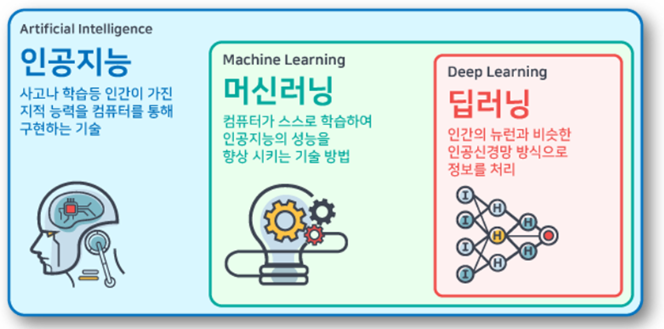

- 기계가 일일이 코드로 명시하지 않은 동작을 **데이터**로부터 **학습**하여 실행할 수 있도록 하는 **알고리즘**을 개발하는 연구 분야
- 머신러닝이란 풀고자 하는 문제의 정답과 데이터를 주고 기계를 학습시켜서 정답을 맞추게 하는 것
- **머신러닝의 대표적인 알고리즘에는 선형회귀, 의사결정나무, 랜덤포레스트, K-최근접 이웃, 클러스터링 등이 존재하며 이 외에도 수많은 알고리즘이 존재함.**

**알고리즘:**문제를 풀기 위한 의사결정 과정  
**데이터:**객관적인 기준을 위한 정답과 요인들  
**학습:**데이터로 부터 최적의 값을 찾는 과정

**[예시]** 현재 내가 살고 있는 집을 팔려고 한다. 얼마가 **적절한 가격**인가?  
**문제: 적절한 가격**

- 집의 가격을 결정하기 위해 주변의 다른 집들의 가격들을 확인
- 집의 가격을 결정하는 몆 가지 요소를 찾음

  ```
    **역에서 가까운지? / 집이 오래 되었는지? / 주차장이 넓은지?**
  ```

- 조사한 요일을 이용해 다음과 같이 집 가격을 알수 있음

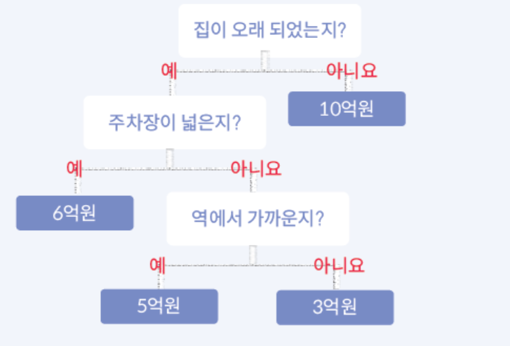

**알고리즘**

- 문제를풀기위한의사결정과정
- 집이낡았음-> 주차장이좁음-> 역에서가까움-> 5억원!

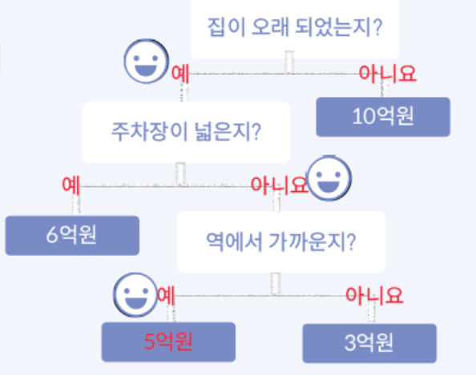

**데이터**

- 주관적인 기준이 아닌 수치에 근거한 객관적인 기준

  ```
    가깝다-> 10km 이내
    오래되었다-> 10년이넘었다
    주차장이크다-> 주차장이100𝑚!보다크다
  ```

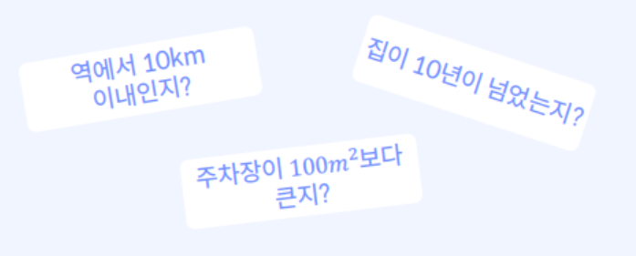

**[학습]**

- 수치에 들어갈 값을 컴퓨터가 스스로 찾는다!

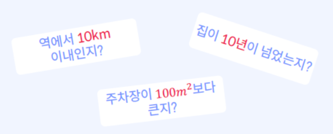

[머신러닝이란?]

- 기계가 일일이 코드로 명시하지 않은 동작을 데이터로 부터 학습하여 실행할 수 있도록 하는 알고리즘을 개발하는 연구 분야 **풀고자 하는 문제의 정답과 데이터를 주고 기계를 학습시켜서 정답을 맞추게 하는 것**

## 2. 머신러닝 필수개념

- 지도학습, 비지도학습, 강화학습

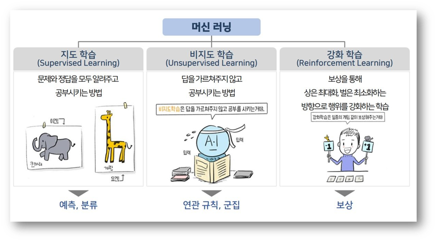

### 2.1 지도 학습(Supervised Learning)

- 정답이 있는 문제를 풀 경우
- 학습은 데이터에 레이블(정답)이 미리 정해져 있을 때 가능
- 정답이 존재한다는 것 자체가 나중에 답을 맞히려고 본다는 것,
- 따라서 지도학습은 답을 찾기 위해 활용되는 알고리즘이라고 할 수 있음.
- 최종적으로 프고그램에 입력값을 주면 출력값을 기계가 예측해 전달함
- 지도 학습은 학습 결과를 바탕으로 미래의 무엇을 예측하냐에 따라 분류, 회귀, 예측으로 구분

#### 2.1.1 회귀(Regression)

- 입력된 데이터에 대하여 연속된 값으로 예측합니다.
- 트레이닝 데이터를 이용하여 연속적인 값을 예측하는 것을 말합니다.
- 예: 키를 이용해 몸무게 예측하기
- 회귀 단어의 유래

  ```
    회귀(regress)의 원래 의미는 옛날 상태로 돌아가는 것을 의미한다.
    영국의 유전학자 프랜시스 골턴이 부모의 키와 아이들의 키 사이의 연관 관계에 대해 연구
  ```

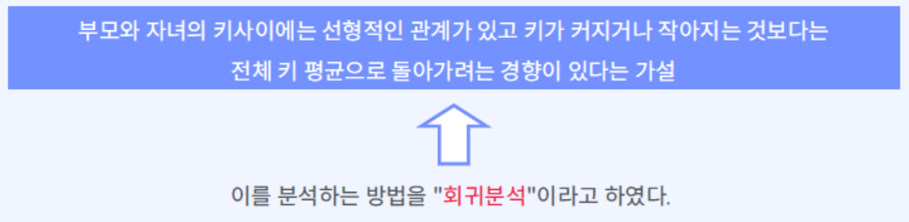

- 데이터들을 쭉 뿌려놓고 이것을 가장 잘 설명하는 직선 하나 혹은 이차함수 곡선 하나를 그리고 싶을 때 회귀기능을 사용합니다.
- 통계학에서 주로 사용되는 회귀 분석(regression analysis)이란 여러 자료들 간의 관계성을 수학적으로 추정하고 분석하는 데이터 분석 방법 중 하나입니다.
- 이러한 회귀 분석은 주로 시간에 따라 변화하는 데이터나 가설, 인과 관계 등의 통계적 예측에 사용됩니다.
- 회귀 분석은 주로 시간에 따라 변화하는 데이터나 가설, 인과 관계 등의 통계적 예측에 사용됩니다.
- 회귀 분석에서 종속변수란 우리가 알고 싶어 하는 결괏값을 가리키며, 독립변수란 이러한 결괏값에 영향을 주는 입력값을 가리킵니다.
- 하나의 종속변수와 하나의 독립변수 사이의 관계를 분석할 경우를 단순 회귀 분석(simple regression analysis)이라고 구분하여 부릅니다.

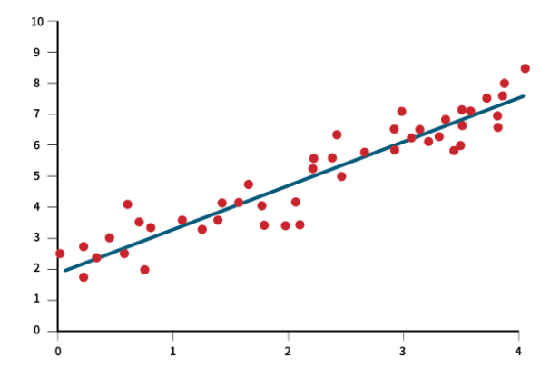

#### 2.1*.2* 분류(Classification)

- 레이블이 달린 학습 데이터로 학습한 후에 새로 입력된 데이터가 학습했던 어느 그룹에 속하는 지를 찾아내는 방법입니다.
- 분류 모델의 결괏값은 언제나 학습했던 데이터의 레이블 중 하나가 됩니다.
- 레이블 y가 이산적(Discrete)인 경우 즉, y가 가질 수 있는 값이 [0,1,2 ..]와 같이 유한한 경우 분류, 혹은 인식 문제라고 부릅니다.
- 일상에서 가장 접하기 쉬우며, 연구가 많이 되어있고, 기업들이 가장 관심을 가지는 문제 중 하나입니다.
- 이런 문제들을 해결하기 위한 대표적인 기법들로는 로지스틱 회귀법, KNN, 서포트 벡터 머신 (SVM), 의사 결정 트리 등이 있습니다.

  ```
    예시1) ‘가’, ‘나’, ‘다’라는 레이블이 달린 데이터를 분류 모델로 지도 학습한 후,
    새로운 데이터를 분석한 결과는 반드시 ‘가’, ‘나’, ‘다’ 중의 하나가 되는 것입니다.

    예시2) 주차게이트에서 번호판 인식
    요새 주차장들은 티켓을 뽑지 않고, 차량 번호판을 찍어서 글자를 인식하는데 정확도를 높인다.
    번호판은 정형화 되어있으므로 전통적인 컴퓨터 비전으로도 처리는 가능하나, 오염 등에 대해 정확도를 높이자면 기계학습을 하면 더 좋다.
    이미지 픽셀 값들에 따라 숫자 글자를 분류한다.

    예시3) 페이스북이나 구글 포토의 얼굴 인식: 역시 컴퓨터 비전을 이용하되 기계학습을 결합.
    페이스북에 사진을 올리면 친구 얼굴 위에 이름이 자동으로 달리고는 하는데, 이것 역시 기계학습을 이용한 것.
    x가 이미지 픽셀, y가 사람 이름인 경우.

    예시4) 음성 인식: 음성 wav 파일에 대해서 해당 wav 부분이 어떤 음절인지를 인식하는 것.
    애플 시리, 구글 보이스 등에서 사용된다(질문에 대해서 답해주는 부분 말고, 인식 부분만).
    x가 음성 파형, y가 음절.
  ```

- **[이진분류]** 예/아니요, 남자/여자 와 같이 둘중 하나를 분류하는 경우
- **[다중분류]** 빨강/파랑/노랑 중 하나의 색을 분류하거나 0부터 9까지 손글씨 술자 중 하나의 숫자로 분류하는 것과 같이 여러 분류값 중 하나의 값을 예측하는 경우
- **[다중 레이블 분류]**
  - 데이터가 입력되었을 때 두 개 이상의 레이블로 분류할 경우 다중 레이블 분류라고 함
  - 분류값으로 세모/네모/동그라미가 있을 경우 문제로 동그라미/세모가 입력된 경우

### 2.2 비지도 학습(Unsupervised Learning)

- 레이블(정답)이 정해져 있지 않은 데이터를 기반으로 데이터의 고유한 구조나 패턴을 익히는 것
- 정답을 주지 않으므로 비지도학습은 답을 맞히는 목적으로 학습하지는 않음.
- 하지만 어떤 데이터들이 서로 비슷한지 그룹지어주거나, 어떤 성질이 데이터를 잘 정의하는 지를 판단하는 등 답을 내지 않는 문제에 대해 나름대로 유용한 정보를 제공해주는 역할을 함.

**비지도 학습의 대표적인 예로 다음과 같은 사례들을 들 수 있음**.

- 구글 뉴스 서비스: 비슷한 주제의 뉴스끼리 묶어줌
- 단어 클러스터링: 유사한 단어끼리 묶어줌

비지도 학습은 **위조 됐거나 손상된 장비같은 이상 결과를 추적**하는데 사용하거나  
마케팅 활동을 위해 유사한 온라인 행동 패턴을 지닌 고객을 그룹화하는 등에 사용됩니다.

- 개와 고양이 사진 구분을 목적으로 사진들을 입력하는 상황을 생각해보면.
- 비지도학습에서는 어느 사진이 개인지 고양이인지 알려주지 않습니다.(즉 레이블링 하지 않음.)
- 하지만 알고리즘은 사진을 보고 어떤 그래서 고양이처럼 생긴 사진끼리 한 그룹으로, 개처럼 생긴 사진끼리 또 다른 그룹으로 구분하게 됨.
- **이렇게 구분은 할 수 있지만 이 그룹의 정체는 알려주지 못함.**
- **따라서 구분이 잘 되었는지, 그리고 그 그룹을 어떻게 정의하는지 최종 판단하는 것은 사람의 몫이다.**

#### 2.2.1 군집분석(클러스터링: Clustering)

- 특정 기준에 따라 유사한 데이터 사례들을 하나의 세트로 그룹화합니다.
- 이 과정은 종종 전체 데이터 세트를 여러 글부으로 분류하기 위해 사용됩니다.
- 사용자는 고유한 패턴을 찾기 위해 개별 그룹 차원에서 분석을 수행할 수 있습니다.

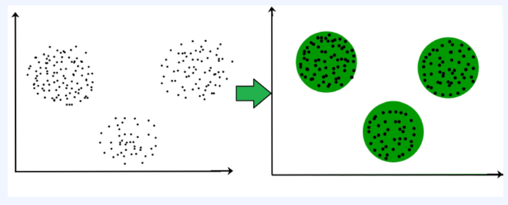

### 2.3 강화학습(Reinforcement learning)

- 환경으로부터의 피드백을 기반으로 행위자(agent)의 행동을 분석하고 최적화 합니다.
- 기계는 어떤 액션을 취해야 할지 듣기 보다는 최고의 보상을 산출하는 액션을 발견하기 위해 서로 다른 시나리오를 시도합니다.
- 시행 착오(Trial-and-error)와 지연 보상(delayed reward)은 다른 기법과 구별되는 강화 학습만의 특징입니다.

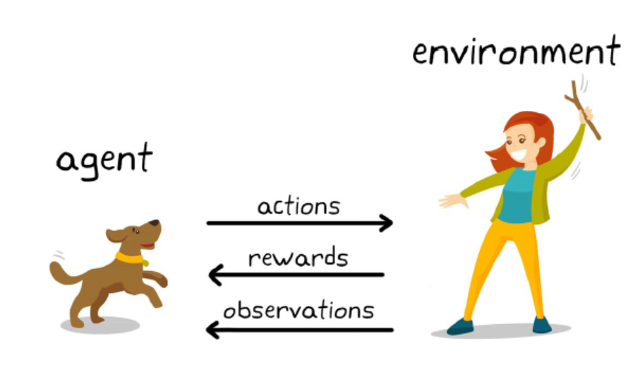

### 머신러닝의 종류

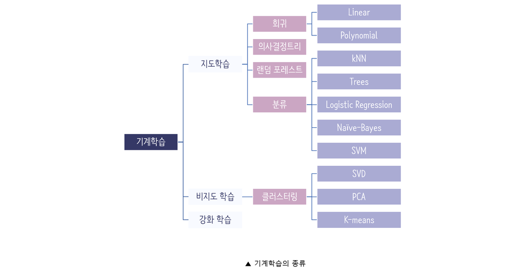

# 머신러닝 필수 개념

## 1. 모델

- 어떤 X가 주어졌을 때 f라는 함수를 통해 y라는 값을 도출하는 과정
- 이때의 함수 f를 모델 또는 알고리즘이라고 부른다.

  ```
    모델의수식
      𝑦 = 𝐹 𝑋
      X : 데이터
      y : 예측값
  ```

- 모델의 목적: 데이터를 이용해 값을 예측
- 모델의 평가: 모델이 값을 잘 예측하는지 평가

## 2. 데이터

- 데이터의 종류
- Train Data
  - 학습에 사용되는 데이터
- Test Data
  - 학습에 사용되지 않은 데이터
  - 모델이 실제로 잘 예측하는지 알기 위해서는 학습에 사용되지 않은 데이터를 이용해 평가해야 한다.

## 3. 모델의 평가와 데이터 관계(과대적합과 과소적합)

- 과소적합(underfitting): 학습데이터를(Train data) 잘 맞추지 못하는 현상
- 과대적합(overfitting): 학습데이터(Train data)는 잘 맞추지만 학습데이터 외에는 잘 맞추지 못하는 현상

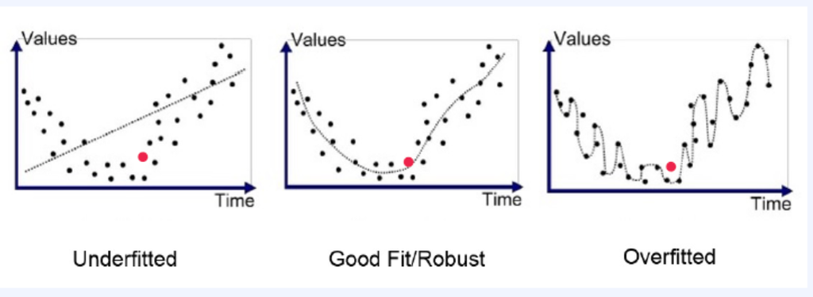

- Underfitting을 확인하는 방법

  ```
    Train data로 학습된 모델을 Train data로평가한다.
    Train data를 잘 맞추지 못한다면 Underfitting 상태
  ```

- Overfitting을 확인하는 방법

  ```
    Train data을 잘 학습한 모델을 Test data로 평가한다.
    Train data는 잘 맞추지만 Test data를 잘 맞추지 못한다면 Overfitting 상태
  ```

### 4. Data split이란?

- 데이터를 Train data와 Test data로 나누는 것
- Train / Test 로 나누기

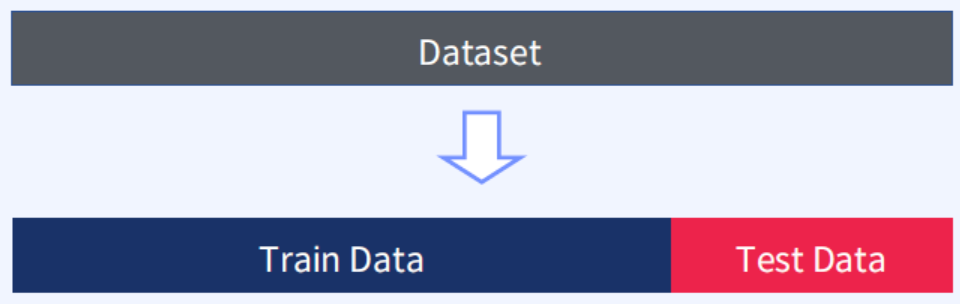

- Train / Valid / Test 로 나누기

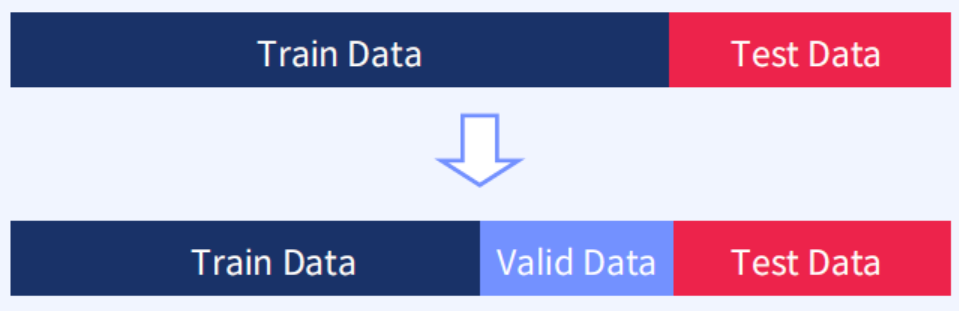

- 각 데이터의 용도
  - Train Data

    ```
    학습에 사용 되는 데이터
    ```

  - Valid Data

    ```
    학습이 완료된 모델을 검증하기 위한 데이터
    학습에 사용 되지는 않지만 관여하는 데이터
    ```

  - Test Data

    ```
    최종 모델의 성능을 검증하기 위한 데이터
    학습에도 사용 되지 않으며 관여하지도 않는 데이터
    학습 시에는 train 셋으로 학습 후 중간 중간 validation 셋으로 내가 학습한 모델을 평가 해주는 것
    ```

- 문제점
  - Valid Data =>학습에 사용되지는 않지만 **관여**하는 데이터
  - Overfitting => Valid 데이터에 Overfitting 될 수도 있음

### 5. 머신러닝 평가 방법

- 회귀문제

  ```
    평균제곱오차(MSE), 결정계수(coefficientg of determination)
  ```

- 분류 문제

  ```
    혼동 행렬(confusion matrix), 정확도(accuracy), 정밀도(precision), 재현율(recall), F값(F1-score), 곡선아래면적(AUC)
  ```

### 5.1 회귀 평가 방법

1) MSE(Mean Squared Error : 평균 제곱 오차)

- 실제값과 예측값의 차이를 제곱해 평균한 것

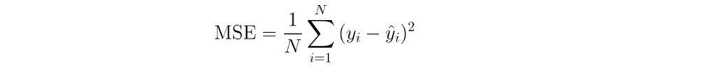

2) RMSE(Root Mean Squared Error : 평균 제곱근 오차)

- MSE값은 오류의 제곱을 구하므로, 실제 오류의 평균보다 값이 더 커지는 특성이 있으므로, MSE에 루트를 씌운 것 (sklearn에서 제공되지 않음)

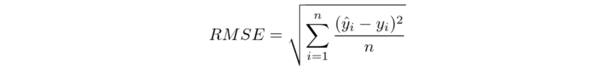

3) MAE(Mean Absolute Error : 평균 절대 오차)

- 실제 값과 예측값의 차이를 절댓값으로 변환해 평균한 것

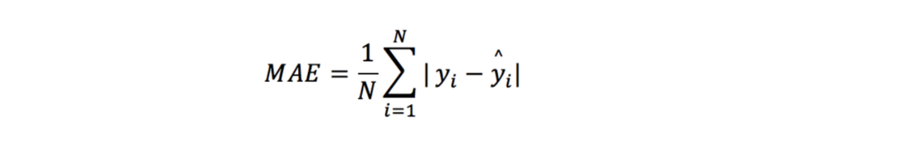

4) MAPE(Mean Absolute Percentage Error : 평균 절대비율 오차 )

- MSE, RMSE의 단점을 보완(sklearn에서 제공되지 않음)

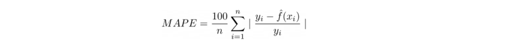

### 5.2 분류 평가 방법

1) 정확도(Accuracy)

- 정확도는 모든 경우의 수 중에서 실제 True와 실제 False(TP, TN)을 올바르게 예측한 비율

  ```
    정확도(Accuracy) = 예측 결과가 동일한 데이터 건수 / 전체 예측 데이터 건수
  ```

- 하지만, 정확도는 데이터의 label이 불균형할때 (즉, 데이터에 편향이 있을때) 실제로 예측하는 성능은 그렇게 좋지 않다.

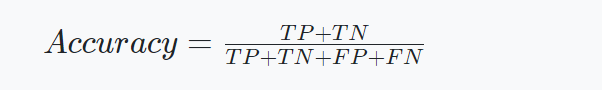

2) 혼동 행렬( confusion matrix ):오차 행렬

- 혼동 행렬은 학습된 분류 모델이 예측을 수행하면서 얼마나 헷갈리고 있는지도 함께 보여주는 지표입니다.
- 어떠한 유형의 예측 오류가 발생하는지를 확인할 수 있습니다.
- **오차 행렬**이라고도 하며 TN, FP, FN, TP 네 가지의 결과를 출력합니다.

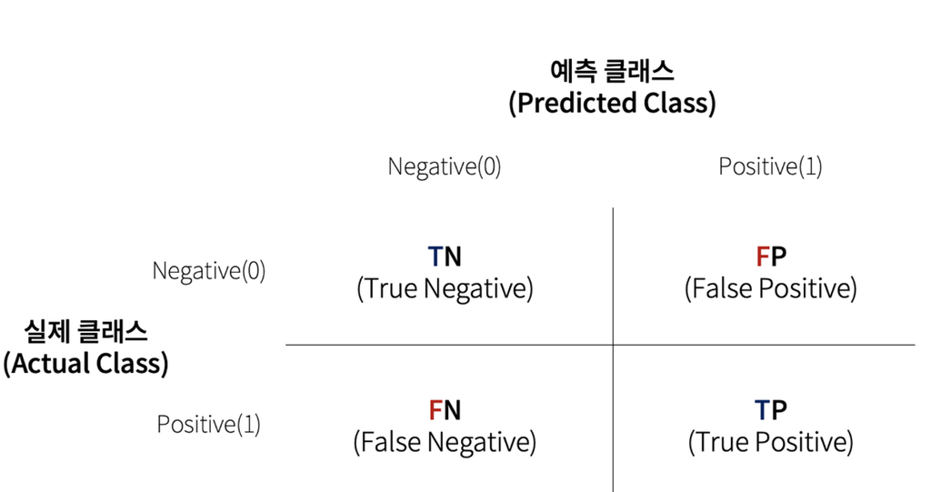

- 모델이 예측한 값을 표현

  ```
    TN(true negative) : 실제 부정 데이터를 부정으로 제대로 예측
    FP(false positive) : 실제 부정 데이터를 긍정으로 잘못 예측
    FN(false negative) : 실제 긍정 데이터를 부정으로 잘못 예측
    TP(true positive) : 실제 긍정 데이터를 긍정으로 제대로 예측
  ```

3) 정밀도(Precision)

- 정밀도는 모델이 True(TP, FP)라고 분류한 것 중에서 실제 True(TP)인 것의 비율

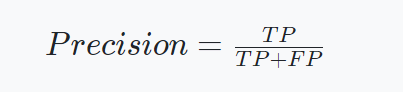

- 정밀도는 불균형한 데이터셋의 모델을 평가하는데도 사용하며, 다음의 경우에 중요하게 사용됩니다.

4) 재현율(Recall)

- 재현율 실제 True(TP, FN)인 것 중에서 모델이 True(TP)라고 예측한 것의 비율
- 민감도, 진짜 양성 비율(TPR)이라고도 불린다.

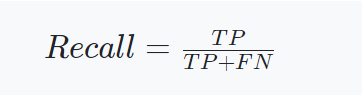

- 재현율은 불균형한 데이터셋의 모델을 평가하는데도 사용하며, 다음의 경우에 가장 중요하게 사용됩니다.

  ```
    1. 암환자에게 암을 예측한 경우 (TP)
    2. 암환자가 아닌 사람에게 암을 예측한 경우 (FP)
    3. 암환자에게 암이 아니라고 예측한 경우 (FN)
    4. 암환자가 아닌 사람에게 암이 아니라고 예측한 경우 (TN)

    1번과 4번은 제대로 예측하였지만, 2번과 3번은 힘든 상황이 발생합니다.
    특히, 3번은 최악의 경우입니다. 따라서 FN을 낮추는데 초점을 두어야합니다.
  ```

5) F1 Score

- F1 Score는 정밀도(Precision)과 재현율(Recall)의 결합한 지표(조화평균)이다.
- 한 쪽으로 치우치지 않는 수치를 나타낼 때 상대적으로 높은 값을 가집니다.
- 데이터 label이 불균형 구조일때, 모델의 성능을 정확하게 평가 할 수 있다는 장점이 있다.

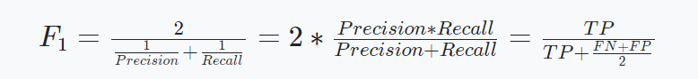

6) ROC 곡선과 AUC

- ROC 곡선(Receiver Operation Characteristic Curve)은 FPR(X축)이 변할때 TPR(Y축)이 어떻게 변호하는지(관계)를 그린 곡선입니다.
- AUC(Area Under Curve)은 ROC 곡선 아래의 면적을 의미합니다.
  - X축: FPR(False Positive Rate)
  - y축: TPR(True Positive Rate) => 재현율, 민감도

    ```
    - 민감도(TPR)는 실제값 Positive(양성)가 정확이 예측돼야 하는 수준을 나타냄
      (질병이 있는 사람은 질병이 있는것으로 양성 판정)
    - 특이성(TNR)은 실제값 Negative(음성)가 정확이 예측돼야 하는 수준을 나타냄
      (질병이 없는 건강한 사람은 질병이 없는 것으로 음성 판정)
    ```

- AUC값은 곡선 밑의 면적을 구한 것으로서 1에 가까울 수록 좋음.

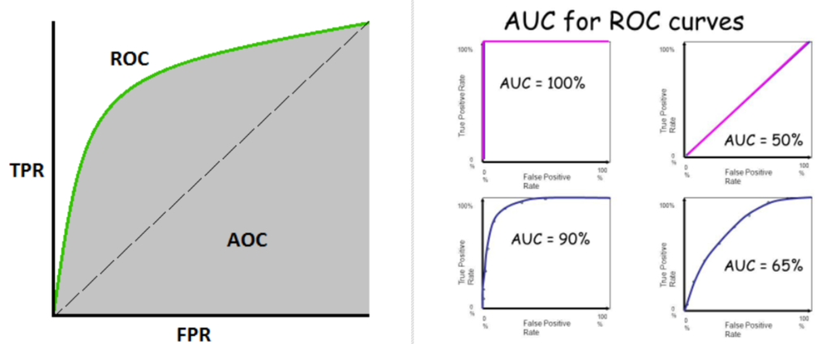

## 6. K-폴드 교차검증

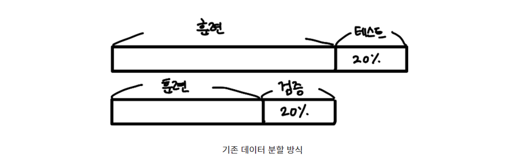

- K-폴드 교차검증 방식

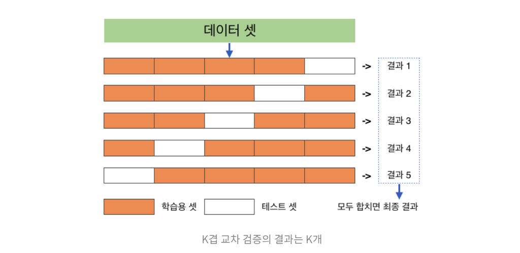